# heart_disease data

Best Model Selection to Predict Risk of Heart Disease

First, we need to import all the required libraries.

```python
import pandas as pd
import numpy as np
import matplotlib.pyplot as plt
import seaborn as sns
import plotly.express as px

from sklearn.model_selection import train_test_split, GridSearchCV
from sklearn.preprocessing import StandardScaler
from sklearn.linear_model import LogisticRegression
from sklearn.tree import DecisionTreeClassifier
from sklearn.ensemble import RandomForestClassifier
from xgboost import XGBClassifier
from sklearn.neural_network import MLPClassifier
from sklearn.svm import SVC
from sklearn.metrics import ConfusionMatrixDisplay, RocCurveDisplay, accuracy_score, precision_score, recall_score, f1_score, roc_curve, auc
```

Importing the dataset and have a look at the first five rows.

```python
heart_data = pd.read_csv('heart_disease_risk_dataset_earlymed.csv')
heart_data.head()
```

|  | Chest_Pain | Shortness_of_Breath | Fatigue | Palpitations | Dizziness | Swelling | Pain_Arms_Jaw_Back | Cold_Sweats_Nausea | High_BP | High_Cholesterol | Diabetes | Smoking | Obesity | Sedentary_Lifestyle | Family_History | Chronic_Stress | Gender | Age | Heart_Risk |
| --- | --- | --- | --- | --- | --- | --- | --- | --- | --- | --- | --- | --- | --- | --- | --- | --- | --- | --- | --- |
| 0 | 0.0 | 0.0 | 0.0 | 1.0 | 0.0 | 0.0 | 0.0 | 0.0 | 0.0 | 0.0 | 0.0 | 1.0 | 0.0 | 1.0 | 0.0 | 0.0 | 0.0 | 48.0 | 0.0 |
| 1 | 0.0 | 1.0 | 0.0 | 1.0 | 0.0 | 0.0 | 0.0 | 0.0 | 1.0 | 0.0 | 0.0 | 1.0 | 1.0 | 0.0 | 0.0 | 0.0 | 0.0 | 46.0 | 0.0 |
| 2 | 1.0 | 0.0 | 0.0 | 1.0 | 0.0 | 0.0 | 0.0 | 0.0 | 1.0 | 1.0 | 0.0 | 1.0 | 1.0 | 1.0 | 0.0 | 0.0 | 1.0 | 66.0 | 0.0 |
| 3 | 1.0 | 1.0 | 0.0 | 1.0 | 0.0 | 0.0 | 1.0 | 1.0 | 1.0 | 0.0 | 1.0 | 1.0 | 0.0 | 1.0 | 1.0 | 1.0 | 1.0 | 60.0 | 1.0 |
| 4 | 0.0 | 0.0 | 1.0 | 0.0 | 1.0 | 0.0 | 0.0 | 0.0 | 0.0 | 0.0 | 1.0 | 0.0 | 0.0 | 0.0 | 0.0 | 0.0 | 0.0 | 69.0 | 0.0 |

Also, check the last five rows to get an idea about the data.

```python
heart_data.tail()
```

|  | Chest_Pain | Shortness_of_Breath | Fatigue | Palpitations | Dizziness | Swelling | Pain_Arms_Jaw_Back | Cold_Sweats_Nausea | High_BP | High_Cholesterol | Diabetes | Smoking | Obesity | Sedentary_Lifestyle | Family_History | Chronic_Stress | Gender | Age | Heart_Risk |
| --- | --- | --- | --- | --- | --- | --- | --- | --- | --- | --- | --- | --- | --- | --- | --- | --- | --- | --- | --- |
| 69995 | 0.0 | 0.0 | 1.0 | 0.0 | 0.0 | 0.0 | 0.0 | 0.0 | 0.0 | 0.0 | 1.0 | 0.0 | 0.0 | 1.0 | 1.0 | 0.0 | 0.0 | 30.0 | 0.0 |
| 69996 | 1.0 | 1.0 | 1.0 | 0.0 | 1.0 | 1.0 | 1.0 | 1.0 | 1.0 | 1.0 | 0.0 | 1.0 | 0.0 | 1.0 | 1.0 | 1.0 | 1.0 | 56.0 | 1.0 |
| 69997 | 0.0 | 0.0 | 0.0 | 0.0 | 0.0 | 0.0 | 1.0 | 0.0 | 0.0 | 0.0 | 1.0 | 0.0 | 0.0 | 0.0 | 0.0 | 1.0 | 1.0 | 53.0 | 0.0 |
| 69998 | 1.0 | 1.0 | 0.0 | 1.0 | 1.0 | 0.0 | 1.0 | 1.0 | 1.0 | 1.0 | 1.0 | 0.0 | 1.0 | 1.0 | 1.0 | 0.0 | 1.0 | 57.0 | 1.0 |
| 69999 | 1.0 | 1.0 | 1.0 | 1.0 | 1.0 | 1.0 | 1.0 | 0.0 | 1.0 | 0.0 | 1.0 | 0.0 | 1.0 | 0.0 | 0.0 | 1.0 | 0.0 | 51.0 | 1.0 |

By looking at the first and last five rows, we can see that this dataset contains all numeric values.

This dataset has 70,000 rows and 19 columns.

```python
heart_data.shape
```

```
(70000, 19)
```

View the summary of data columns and their data types.

```python
heart_data.info()
```

```
<class 'pandas.core.frame.DataFrame'>
RangeIndex: 70000 entries, 0 to 69999
Data columns (total 19 columns):
 #   Column               Non-Null Count  Dtype
---  ------               --------------  -----
 0   Chest_Pain           70000 non-null  float64
 1   Shortness_of_Breath  70000 non-null  float64
 2   Fatigue              70000 non-null  float64
 3   Palpitations         70000 non-null  float64
 4   Dizziness            70000 non-null  float64
 5   Swelling             70000 non-null  float64
 6   Pain_Arms_Jaw_Back   70000 non-null  float64
 7   Cold_Sweats_Nausea   70000 non-null  float64
 8   High_BP              70000 non-null  float64
 9   High_Cholesterol     70000 non-null  float64
 10  Diabetes             70000 non-null  float64
 11  Smoking              70000 non-null  float64
 12  Obesity              70000 non-null  float64
 13  Sedentary_Lifestyle  70000 non-null  float64
 14  Family_History       70000 non-null  float64
 15  Chronic_Stress       70000 non-null  float64
 16  Gender               70000 non-null  float64
 17  Age                  70000 non-null  float64
 18  Heart_Risk           70000 non-null  float64
dtypes: float64(19)
memory usage: 10.1 MB
```

Check whether there are any missing values in each column. The following shows that there are none.

```python
heart_data.isnull().sum()
```

```
Chest_Pain             0
Shortness_of_Breath    0
Fatigue                0
Palpitations           0
Dizziness              0
Swelling               0
Pain_Arms_Jaw_Back     0
Cold_Sweats_Nausea     0
High_BP                0
High_Cholesterol       0
Diabetes               0
Smoking                0
Obesity                0
Sedentary_Lifestyle    0
Family_History         0
Chronic_Stress         0
Gender                 0
Age                    0
Heart_Risk             0
dtype: int64
```

Check whether there are any duplicates available in the dataset. The results shows that there are 6,245 duplicates, which were removed.

```python
heart_data.duplicated().sum()
```

```
np.int64(6245)
```

```python
heart_data = heart_data.drop_duplicates()
```

```python
heart_data.duplicated().sum()
```

```
np.int64(0)
```

Since this is a binary classification problem, there are only two categories - whether some one has a risk of heart disease or not. The following count plot shows the number of positive(1 - at a risk) and negative (0 - not at a risk).

This graph shows there is very small imbalance in the dataset. Since it is insignificant, I decided to proceed without addressing the imbalance using oversampling or undersampling techniques. Instead used hyperparameters such as 'class_weight = 'balanced'' option.

```python
heart_data['Heart_Risk'].value_counts()
```

```
Heart_Risk
0.0    32268
1.0    31487
Name: count, dtype: int64
```

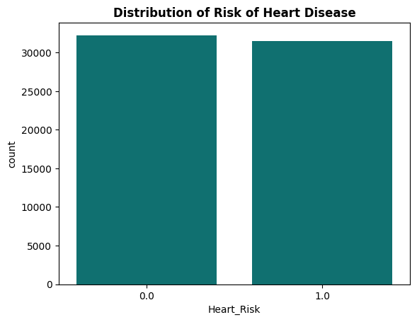

```python
sns.countplot(data = heart_data, x = 'Heart_Risk', color='teal')
plt.title("Distribution of Risk of Heart Disease", fontweight = 'bold')
```

The following method shows all the available column names.

```python
heart_data.columns
```

```
Index(['Chest_Pain', 'Shortness_of_Breath', 'Fatigue', 'Palpitations',
       'Dizziness', 'Swelling', 'Pain_Arms_Jaw_Back', 'Cold_Sweats_Nausea',
       'High_BP', 'High_Cholesterol', 'Diabetes', 'Smoking', 'Obesity',
       'Sedentary_Lifestyle', 'Family_History', 'Chronic_Stress', 'Gender',
       'Age', 'Heart_Risk'],
      dtype='object')
```

[output not shown]

[figure not shown]

```python
plt.figure(figsize = (17,20))
plt.suptitle("Risk of Heart Desease by Each Feature Variable", fontsize = 25, fontweight = 'bold')

plt.subplot(5,4,1)
sns.countplot(data = heart_data, x = 'Chest_Pain', color='cornflowerblue')
plt.yticks(fontsize = 6)

plt.subplot(5,4,2)
sns.countplot(data = heart_data, x = 'Shortness_of_Breath', color= 'cadetblue')
plt.yticks(fontsize = 6)

plt.subplot(5,4,3)
sns.countplot(data = heart_data, x = 'Fatigue', color='darkcyan')
plt.yticks(fontsize = 6)

plt.subplot(5,4,4)
sns.countplot(data = heart_data, x = 'Palpitations', color='dodgerblue')
plt.yticks(fontsize = 6)

plt.subplot(5,4,5)
sns.countplot(data = heart_data, x = 'Dizziness', color='cornflowerblue')
plt.yticks(fontsize = 6)

plt.subplot(5,4,6)
sns.countplot(data = heart_data, x = 'Swelling', color= 'cadetblue')
plt.yticks(fontsize = 6)

plt.subplot(5,4,7)
sns.countplot(data = heart_data, x = 'Pain_Arms_Jaw_Back', color='darkcyan')
plt.yticks(fontsize = 6)

plt.subplot(5,4,8)
sns.countplot(data = heart_data, x = 'Cold_Sweats_Nausea', color='dodgerblue')
plt.yticks(fontsize = 6)

plt.subplot(5,4,9)
sns.countplot(data = heart_data, x = 'High_BP', color='cornflowerblue')
plt.yticks(fontsize = 6)

plt.subplot(5,4,10)
sns.countplot(data = heart_data, x = 'High_Cholesterol', color= 'cadetblue')
plt.yticks(fontsize = 6)

plt.subplot(5,4,11)
sns.countplot(data = heart_data, x = 'Diabetes', color='darkcyan')
plt.yticks(fontsize = 6)

plt.subplot(5,4,12)
sns.countplot(data = heart_data, x = 'Smoking', color='dodgerblue')
plt.yticks(fontsize = 6)

plt.subplot(5,4,13)
sns.countplot(data = heart_data, x = 'Obesity', color='cornflowerblue')
plt.yticks(fontsize = 6)

plt.subplot(5,4,14)
sns.countplot(data = heart_data, x = 'Sedentary_Lifestyle', color= 'cadetblue')
plt.yticks(fontsize = 6)

plt.subplot(5,4,15)
sns.countplot(data = heart_data, x = 'Family_History', color='darkcyan')
plt.yticks(fontsize = 6)

plt.subplot(5,4,16)
sns.countplot(data = heart_data, x = 'Chronic_Stress', color='dodgerblue')
plt.yticks(fontsize = 6)

plt.subplot(5,4,17)
sns.countplot(data = heart_data, x = 'Gender', color='cornflowerblue')
plt.yticks(fontsize = 6)
```

In this dataset Age is only feature/variable that has range of values. All other are binary inputs (1 - Yes or 0 - No)

Therefore, using a histogram, I checked whether it has any outliers and it is not normally distributed. Therefore, the 'Age' feature needs to be normalized.

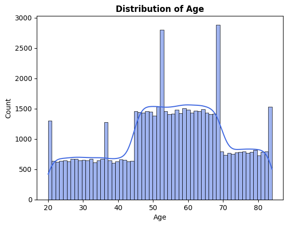

```python
sns.histplot(data = heart_data, x = 'Age', kde = True, color='royalblue', bins = 60)
plt.title('Distribution of Age', fontweight = 'bold')
```

Using a boxplot, it was further verified whether the 'Age' feature has outliers. By looking at the following box plot, we can see that there are no outliers present.

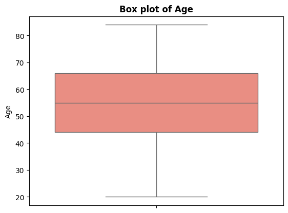

```python
sns.boxplot(data = heart_data, y = 'Age', color='salmon')
plt.title('Box plot of Age', fontweight = 'bold')
```

To get an idea about the correlations between features, a heatmap was used. By observing the heatmap, we can say that the with higher correlation to Heart_Risk are: Chest pain, Shortness of breath, Fatigue, Palpitations, Dizziness, Swelling, Pain in arms/jaw/back, Cold sweats, Nausea and Age. Among these features, except for Age, the rest are recorded after the person had a heart attack. This represents data leakage. So, Those features need to be removed.

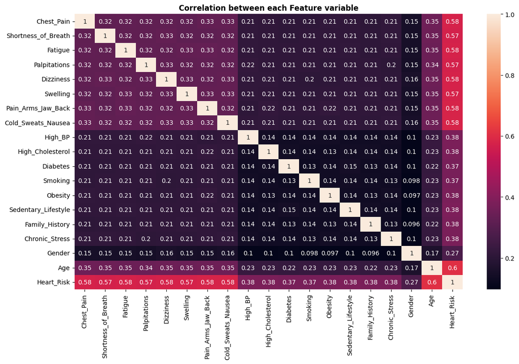

```python
correations = heart_data.corr()

plt.figure(figsize = (14,8))
sns.heatmap(correations, annot = True)
plt.title('Correlation between each Feature variable', fontweight = 'bold')
```

Make a copy of original dataset, and perform all changes on the copy from here onwards.

```python
heart_data_copy = heart_data.copy()
```

Numerical columns are put into an array. In this case 'Age' is only numerical feature.

```python
numerical_cols =  ['Age']
```

Addressing data leackage by ensuring unnecessary columns are removed.

```python
data_leakage_cols = ['Chest_Pain','Shortness_of_Breath','Fatigue','Palpitations','Dizziness','Swelling','Pain_Arms_Jaw_Back',
                        'Cold_Sweats_Nausea']
```

```python
heart_data_copy_cleaned = heart_data_copy.drop(columns = data_leakage_cols)
```

```python
heart_data_copy_cleaned.columns
```

```
Index(['High_BP', 'High_Cholesterol', 'Diabetes', 'Smoking', 'Obesity',
       'Sedentary_Lifestyle', 'Family_History', 'Chronic_Stress', 'Gender',
       'Age', 'Heart_Risk'],
      dtype='object')
```

Define X and y

```python
y = heart_data_copy_cleaned['Heart_Risk']
X = heart_data_copy_cleaned.drop(columns = 'Heart_Risk')
```

```python
X.columns
```

```
Index(['High_BP', 'High_Cholesterol', 'Diabetes', 'Smoking', 'Obesity',
       'Sedentary_Lifestyle', 'Family_History', 'Chronic_Stress', 'Gender',
       'Age'],
      dtype='object')
```

Split the data into training and testing sets.

```python
X_train, X_test, y_train, y_test = train_test_split(X,y, test_size = 0.2, random_state=12, stratify= y )
```

Normalizing the X data

```python
scaler = StandardScaler()

X_train_scaled = scaler.fit_transform(X_train[numerical_cols])
X_test_scaled = scaler.transform(X_test[numerical_cols])
```

Verify that the data has been normalized correctly. Normalized data should have a mean of zero and a standard deviation of one.

```python
round(np.mean(X_test_scaled),2)
```

```
np.float64(-0.01)
```

```python
round(np.std(X_test_scaled),2)
```

```
np.float64(1.0)
```

Defining all the machine learning algorithms expected to be used for this dataset.

```python
model_1 = LogisticRegression(random_state=12, class_weight='balanced')
model_2 = DecisionTreeClassifier(random_state=12, class_weight='balanced')
model_3 = RandomForestClassifier(random_state=12, class_weight='balanced')
model_4 = XGBClassifier()
model_5 = MLPClassifier(random_state=12, max_iter=500)
```

```python
params_1 = {
    'C':[0.01,0.1,1,1.5,2],
    'max_iter': [100,150,200,250],
    'solver': ['lbfgs','liblinear','sag','saga']
}

params_2 = {
    'max_depth': [5,10,15,20],
    'min_samples_split': [2,3,4]
}

params_3 = {
    'n_estimators': [100,200,250],
    'max_depth': [2,5,10,15],
    'min_samples_split': [2,3,4]
}

params_4 = {
    'scale_pos_weight': [1,2,3],    #using when the dataset is imbalances
    'learning_rate': [0.001,0.01,0.1,0.3],
    'gamma': [0,1,2,3,4]

}

params_5 = {
    'hidden_layer_sizes': [(16,),(16,32)],
    'solver':['adam','sgd','lbfgs'],
    'alpha':[0.001,0.01,0.1,0.5]
}
```

```python
grid_1 = GridSearchCV(model_1, params_1, cv = 5, scoring='f1')
grid_1.fit(X_train_scaled, y_train)

print(grid_1.best_params_)
print(grid_1.best_score_)
```

```
{'C': 0.1, 'max_iter': 100, 'solver': 'sag'}
0.7215579898715824
```

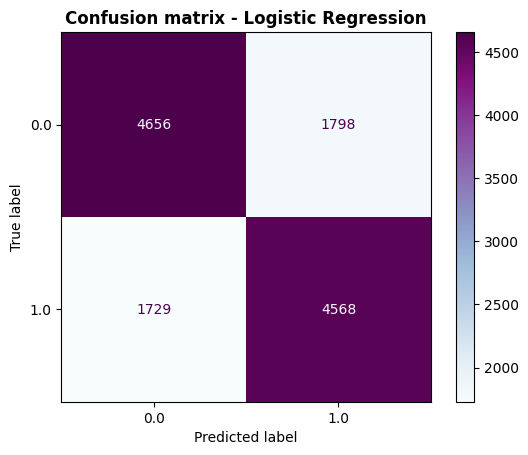

```python
model1 = LogisticRegression(random_state=12, class_weight='balanced',max_iter=100, C = 0.1, solver='sag')
model1.fit(X_train_scaled,y_train)
pred_y_1 = model1.predict(X_test_scaled)
ConfusionMatrixDisplay.from_predictions(y_test, pred_y_1, cmap = 'BuPu')
plt.title("Confusion matrix - Logistic Regression", fontweight = 'bold')
```

```python
print("Accuracy  : ",round(accuracy_score(y_test, pred_y_1),2))
print("Precision : ",round(precision_score(y_test, pred_y_1),2))
print("Recall    : ",round(recall_score(y_test, pred_y_1),2))
print("f1_Score  : ",round(f1_score(y_test, pred_y_1),2))
```

```
Accuracy  :  0.72
Precision :  0.72
Recall    :  0.73
f1_Score  :  0.72
```

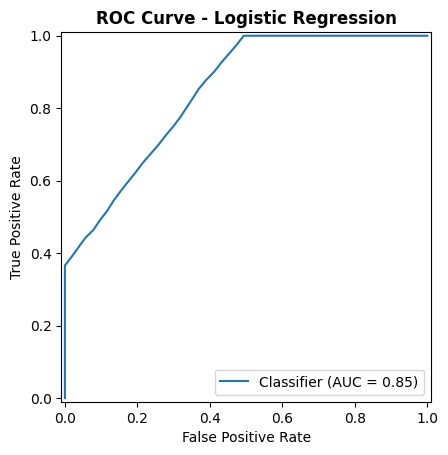

```python
y_scores  = model1.predict_proba(X_test_scaled)[:,1]
RocCurveDisplay.from_predictions(y_test,y_scores)
plt.title("ROC Curve - Logistic Regression", fontweight = 'bold')  # based on positive label 1
plt.xlabel("False Positive Rate")
plt.ylabel("True Positive Rate")
```

```python
grid_2 = GridSearchCV(model_2, params_2, cv = 5, scoring = 'f1')
grid_2.fit(X_train, y_train)

print(grid_2.best_params_)
print(grid_2.best_score_)
```

```
{'max_depth': 10, 'min_samples_split': 2}
0.9253275494186555
```

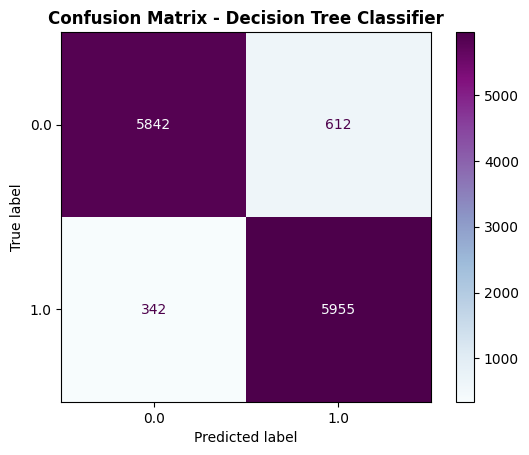

```python
model2 = DecisionTreeClassifier(random_state=12, class_weight='balanced', max_depth=10, min_samples_split=2)
model2.fit(X_train, y_train)
pred_y_2 = model2.predict(X_test)
ConfusionMatrixDisplay.from_predictions(y_test, pred_y_2, cmap = 'BuPu')
plt.title("Confusion Matrix - Decision Tree Classifier", fontweight = 'bold')
```

```python
print("Accuracy  : ",round(accuracy_score(y_test, pred_y_2),2))
print("Precision : ",round(precision_score(y_test, pred_y_2),2))
print("Recall    : ",round(recall_score(y_test, pred_y_2),2))
print("f1_Score  : ",round(f1_score(y_test, pred_y_2),2))
```

```
Accuracy  :  0.93
Precision :  0.91
Recall    :  0.95
f1_Score  :  0.93
```

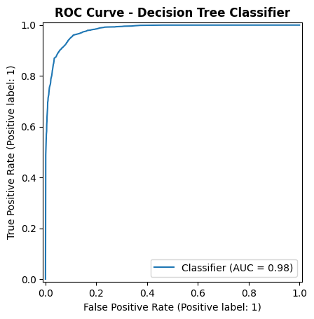

```python
y_scores = model2.predict_proba(X_test)[:,1]

RocCurveDisplay.from_predictions(y_test, y_scores)
plt.title("ROC Curve - Decision Tree Classifier", fontweight = 'bold')
plt.xlabel("")
```

```python
grid_3 = GridSearchCV(model_3, params_3, cv = 5, scoring = 'f1')
grid_3.fit(X_train, y_train)

print(grid_3.best_params_)
print(grid_3.best_score_)
```

```
{'max_depth': 10, 'min_samples_split': 3, 'n_estimators': 200}
0.9327160867332672
```

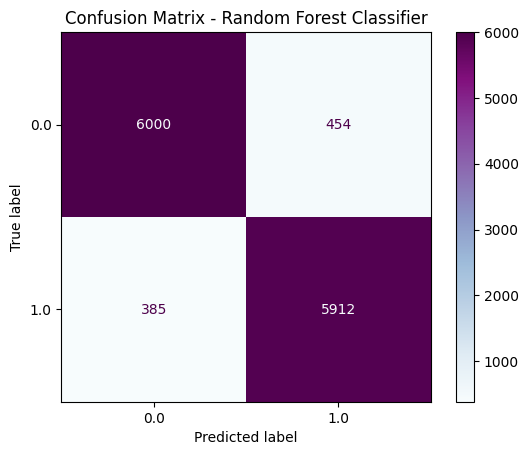

```python
model3 = RandomForestClassifier(random_state=12, class_weight='balanced', max_depth=10, min_samples_split=3, n_estimators=200)
model3.fit(X_train, y_train)
pred_y_3 = model3.predict(X_test)
ConfusionMatrixDisplay.from_predictions(y_test, pred_y_3, cmap = 'BuPu')
plt.title("Confusion Matrix - Random Forest Classifier")
```

```python
print("Accuracy  : ",round(accuracy_score(y_test, pred_y_3),2))
print("Precision : ",round(precision_score(y_test, pred_y_3),2))
print("Recall    : ",round(recall_score(y_test, pred_y_3),2))
print("f1_Score  : ",round(f1_score(y_test, pred_y_3),2))
```

```
Accuracy  :  0.93
Precision :  0.93
Recall    :  0.94
f1_Score  :  0.93
```

```
<sklearn.metrics._plot.roc_curve.RocCurveDisplay at 0x2690d35d310>
```

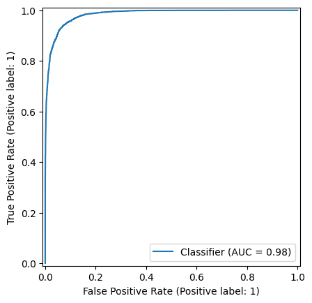

```python
y_scores = model3.predict_proba(X_test)[:,1]

RocCurveDisplay.from_predictions(y_test, y_scores)
```

```python
grid_4 = GridSearchCV(model_4, params_4, cv = 5, scoring='f1')
grid_4.fit(X_train, y_train)

print(grid_4.best_params_)
print(grid_4.best_score_)
```

```
{'gamma': 3, 'learning_rate': 0.1, 'scale_pos_weight': 1}
0.9343608564851852
```

```
<sklearn.metrics._plot.confusion_matrix.ConfusionMatrixDisplay at 0x2690d3c1ed0>
```

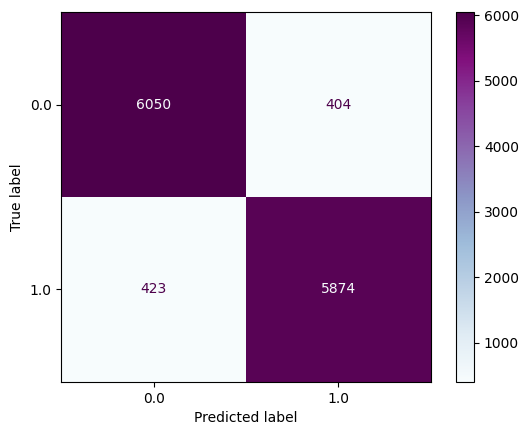

```python
model4 = XGBClassifier(gamma = 3, learning_rate = 0.1, scale_pos_weight = 1)
model4.fit(X_train, y_train)
pred_y_4  =model4.predict(X_test)
ConfusionMatrixDisplay.from_predictions(y_test, pred_y_4, cmap = 'BuPu')
```

```python
print("Accuracy  : ",round(accuracy_score(y_test, pred_y_4),2))
print("Precision : ",round(precision_score(y_test, pred_y_4),2))
print("Recall    : ",round(recall_score(y_test, pred_y_4),2))
print("f1_Score  : ",round(f1_score(y_test, pred_y_4),2))
```

```
Accuracy  :  0.94
Precision :  0.94
Recall    :  0.93
f1_Score  :  0.93
```

```
<sklearn.metrics._plot.roc_curve.RocCurveDisplay at 0x2691567b650>
```

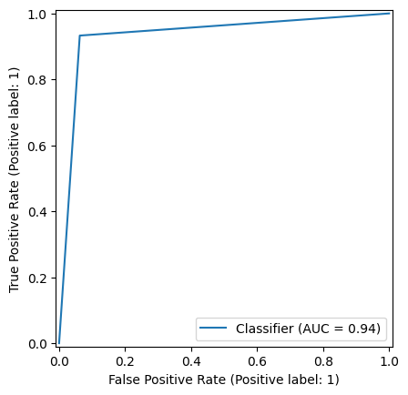

```python
y_scores = model4.predict_proba(X_test)[:,1]

RocCurveDisplay.from_predictions(y_test, pred_y_4)
```

```python
grid_5 = GridSearchCV(model_5, params_5, cv = 5, scoring = 'f1')
grid_5.fit(X_train_scaled, y_train)

print(grid_5.best_params_)
print(grid_5.best_score_)
```

```
{'alpha': 0.001, 'hidden_layer_sizes': (16,), 'solver': 'adam'}
0.7948394888509815
```

```
<sklearn.metrics._plot.confusion_matrix.ConfusionMatrixDisplay at 0x269156f6590>
```

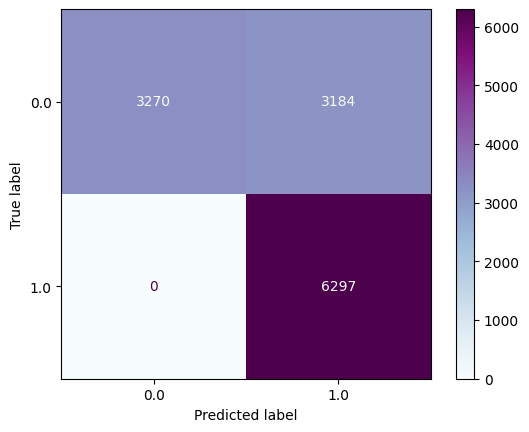

```python
model5 = MLPClassifier(random_state=12, max_iter=500, alpha=0.001, hidden_layer_sizes=(16,), solver='adam')
model5.fit(X_train_scaled, y_train)
pred_y_5 = model5.predict(X_test_scaled)
ConfusionMatrixDisplay.from_predictions(y_test, pred_y_5, cmap = 'BuPu')
```

```python
print("Accuracy  : ",round(accuracy_score(y_test, pred_y_5),2))
print("Precision : ",round(precision_score(y_test, pred_y_5),2))
print("Recall    : ",round(recall_score(y_test, pred_y_5),2))
print("f1_Score  : ",round(f1_score(y_test, pred_y_5),2))
```

```
Accuracy  :  0.75
Precision :  0.66
Recall    :  1.0
f1_Score  :  0.8
```

```
<sklearn.metrics._plot.roc_curve.RocCurveDisplay at 0x2691574c410>
```

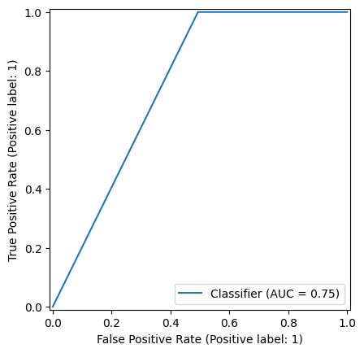

```python
y_scores = model5.predict_proba(X_test_scaled)[:,1]

RocCurveDisplay.from_predictions(y_test, pred_y_5)
```

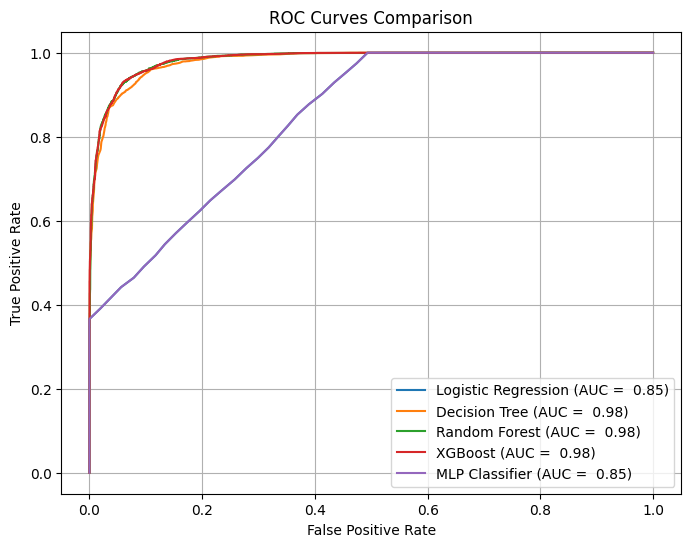

```python
plt.figure(figsize = (8,6))

models = [
    ("Logistic Regression", model1, X_test_scaled),
    ("Decision Tree", model2, X_test),
    ("Random Forest", model3, X_test),
    ("XGBoost", model4, X_test),
    ("MLP Classifier", model5, X_test_scaled)
]

for name, model, X in models:
    y_scores = model.predict_proba(X)[:,1]   #[:,1] means “take the probability of the positive class (1)” for every sample.
    fpr, tpr, _ = roc_curve(y_test, y_scores)
    roc_auc = auc(fpr, tpr)
    plt.plot(fpr, tpr, label =f"{name} (AUC = {roc_auc: .2f})")

plt.xlabel("False Positive Rate")
plt.ylabel("True Positive Rate")
plt.title("ROC Curves Comparison")
plt.legend(loc = "lower right")
plt.grid(True)
plt.show()
```